# Sorting Algorithms

Ken Wu

7/13/2021

## Mergesort Algorithm

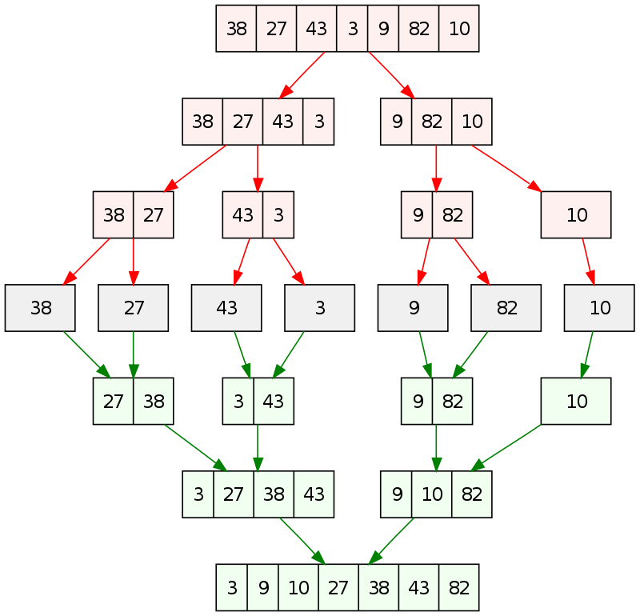

```r
# Import image
knitr::include_graphics("Mergesort.png")
```

## Implementation 1: Rosetta code at [Link](http://www.jason-french.com/blog/2014/07/26/recursion-in-r/)

- Two functions are involved in this algorithm: a merge() function for comparing values and merging sub-vectors
- A mergesort() function that recursively calls itself to divide the vector into length-one sub-vectors.

```r
mergesort <- function(x) {

  # A merge function to compare and append values to result container in order
  merge <- function(left, right) {

    # Create an empty container to hold the results
    result <- vector(mode = "double", length = 0)

    # This is the stop condition. While (as long as) left & right sub-vectors still have a value
    # Compare them and insert them into the container in order
    # That is, if the condition in while() evaluates to TRUE, run the action in {}
    while (length(left) > 0 && length(right) > 0) {
      # If the value in the left sub-vector is less than or equal to that in the right,
      # Add the left value to the container
      if (left[[1]] <= right[[1]]) {
        result <- c(result, left[[1]])
        # Remove that value from the left sub-vector
        left <- left[-1]
      } else {
        # If the value in the right sub-vector is less than or equal to that in the left,
        # add the right value to the container
        result <- c(result, right[[1]])
        # Remove that value from the right sub-vector
        right <- right[-1]
      }
    }

    # Keep comparing and inserting the values into the container
    if (length(left) > 0) result <- c(result, left)
    if (length(right) > 0) result <- c(result, right)
    # Output
    result
  }


  # This is the terminating condition for the mergesort function
  # When the length of the vector is one, just return length-one vector itself
  len <- length(x)
  if (len <= 1) {
    x
  } else {

    # Otherwise keep dividing the vector into two halves
    middle <- length(x) / 2
    # Add every element from the left of the middle to the left sub-vector
    # Use ceiling to handle cases where there is an odd number of elements in "x"
    left <- x[1:ceiling(middle)]
    # Add every element from the right of the middle to the right sub-vector
    right <- x[ceiling(middle + 1):len]
    # Recursively call mergesort() on the left and right sub-vectors
    left <- mergesort(left)
    right <- mergesort(right)

    # Order and combine the results
    # The condition below should evaluate to a single T/F
    if (left[length(left)] <= right[1]) {
      c(left, right)
    } else {
      merge(left, right)
    }
  }
}
```

## Implementation 2: Geeksforgeeks at [Link](https://www.geeksforgeeks.org/types-of-sorting-algorithm-in-r-programming/)

- The && (AND) and || (OR) are non-vectorized operators; they consider only the first element of the vectors and give a vector of single element as output.

```r
# A function to merge two sorted vectors
merge <- function(x, y) {

  # Pre-allocate container vector (all 0's) with length equaling the length of x and y combined
  container <- vector(mode = "double", length = length(x) + length(y))

  # Initialize i & j pointing to the first indices of the sorted vectors x & y
  # Initialize k which points to the first index of the container
  i <- 1
  j <- 1
  k <- 1
  for (k in 1:length(container)) {
    # If i is less than the length of x AND x[i] < y[j]
    # Or if j is larger than the length of y
    # Use [ instead of [[ since the latter returns an error when either i or j is out-of-bounds
    # Out-of-bounds with [ returns an NA and (NA || TRUE) evaluates to TRUE
    if ((i <= length(x) && x[i] < y[j]) || j > length(y)) {
      # Insert x[[i]] into the container and increment i to the next index
      # Index j remains unchanged when this action is executed
      container[[k]] <- x[[i]]
      i <- i + 1
    } else {
      # Otherwise, insert y[[j]] into the container and increment j to the next index
      # Index i remains unchanged when this action is executed
      container[[k]] <- y[[j]]
      j <- j + 1
    }
  }

  # Output
  container
}
```

## Chart Flow (Partial)

1. Lines 109 thru 116: Pre-allocate output container and initialize indices.
2. line 117: Set k to 1; i is 1 and j is 1.
- If the condition in () evaluates to TRUE, the first element of the x vector is sub-assigned to the first element of container. Then, i is incremented by 1 while j is unchanged.
- If the condition in () evaluates to FALSE, the first element of the y vector is sub-assigned to the first element of container. Then, j is incremented by 1 while i is unchanged.

End of if statement. Return to line 117.

```r
# A Function to sort a vector
mergesort <- function(x) {

  # If length of vector is greater than 1,
  # Then perform sorting
  if (length(x) > 1) {

    # Find mid point through which the vector must be divided
    mid <- ceiling(length(x) / 2)

    # First part of array will be from 1 to mid
    a <- mergesort(x[1:mid])

    # second part of array will be from (mid + 1) to length(x)
    b <- mergesort(x[(mid + 1):length(x)])

    # Merge above sorted arrays
    merge(a, b)
  }
  # Else just return vector with single element
  else {
    x
  }
}
```

```r
# Take sample input
x <- sample(x = 1:100, size = 10)
# Call mergeSort function
mergesort(x)
 [1]  7 17 24 32 34 42 51 65 67 72
```